# Metagenome Analysis

Only ancestral, streptomycin and control treatments are included, unless otherwise stated.

Authors

Niina Smolander

Shane Hogle

# Libraries and functions

Prior to this analysis, the variants have been filtered using Mutect2’s FilterMutectCalls as well as separately for SNPs and INDELs using the following hard filtering factors: SOR, FS, MQ, MQRankSum, ReadPosRankSum, SNP/INDEL clustering (3/35) and SNP/INDEL proximity.

```r
library(tidyverse)
library(Polychrome)
library(withr)
library(fs)
library(compositions)
library(vegan)
library(qvalue)

source("data/input/utils_parallelism.R")
```

# 1) Variant trajectories

Nonsynonymous variant allele frequencies at the beginning and at the end of the experiment (t0 and t3) of the genes found to be significantly parallel at t3 (see the table in the section parallelism, inspecting individual genes (2.3)). Gene names used where available, otherwise prokka annotations or descriptions from eggnog are used in the title. Different variants within a gene are separated with the color of the line. The HAMBI proportions (from the 16S amplicon data) are indicated with the transparency of the point.

```r
species_counts_md <- read.delim("data/input/species_counts_md.tsv")

counts <- species_counts_md %>% filter(day == 0 | day == 84) %>%
  group_by(measure_env, evolution_env, replicate, day) %>%
  mutate(read_sum = sum(count_correct)) %>%
  ungroup() %>%
  mutate(proportion = count_correct/read_sum)


par_genes <- read_tsv("data/results/enriched_parallel_genes.tsv")

variants_strep <- read_rds("data/input/variants_strep.rds")

variants_par <- inner_join(variants_strep, par_genes, by = join_by(Home, Measure, GENE == "locus_tag")) %>%
  mutate(gene_label = ifelse(Preferred_name == "-" | is.na(Preferred_name), prokka_annotation, Preferred_name)) %>%
  mutate(gene_label = ifelse(gene_label == "hypothetical protein", Description, gene_label)) %>%
  mutate(gene_label = ifelse(gene_label == "-" | is.na(gene_label), GENE, gene_label)) %>%
  select(HAMBI, GENE, CHROM, POS, ALT, VAF, home_env, measure_env, replicate, gene_label) %>%
  group_by(GENE, home_env, measure_env) %>%
  mutate(count_repl = n_distinct(replicate)) %>%
  ungroup()

t0 <- variants_strep %>%
  filter(Timepoint == "t0") %>%
  select(HAMBI, GENE, CHROM, POS, ALT, VAF, home_env, replicate) %>%
  semi_join(variants_par, by = join_by(HAMBI, GENE, CHROM, POS, ALT, home_env, replicate))

all <- left_join(variants_par, t0, by = join_by(HAMBI, GENE, CHROM, POS, ALT, home_env, replicate),
                 suffix = c("_t3", "_t0")) %>%
  mutate(VAF_t0 = ifelse(is.na(VAF_t0), 0, VAF_t0)) %>%
  pivot_longer(cols = c("VAF_t0", "VAF_t3")) %>%
  mutate(group = paste(GENE, CHROM, POS, ALT, home_env, replicate, sep = "_"),
         name = str_remove_all(name, "VAF_"),
         variant = paste(CHROM, POS, ALT, sep = "_"))

all_filt <- all %>%
  filter(count_repl >= 2)


all_filt <- all_filt %>%
  mutate(measure_env2 = ifelse(name == "t0", "none",
                              ifelse(measure_env == "Meas: BS", "bact_strep", "bact")),
         home_env2 = ifelse(home_env == "Home: B", "bact",
                           ifelse(home_env == "Home: BS", "bact_strep",
                                  "anc")))

counts <- counts %>%
  mutate(day = ifelse(day == 0, "t0",
                      ifelse(day == 84, "t3", day)))


all_filt <- left_join(all_filt, select(counts, proportion, count_correct, day, strainID, replicate, evolution_env, measure_env),
          by = join_by(home_env2 == evolution_env, measure_env2 == measure_env, name == day, replicate, HAMBI == strainID)) %>%
  mutate(alpha_val = ifelse(proportion >= 0.05, 1,
                        ifelse(proportion <= 0.01, 0.1, 0.5)),
         alpha_val = as.factor(alpha_val))


plot <- list()
for(i in unique(all_filt$HAMBI)){
  name <- i

  data <- all_filt[all_filt$HAMBI == name,]

  nicepalette <- unname(createPalette(length(unique(data$variant)), c("#FF1493", "#FFD700"),
                                      M=5000))
  plot[[name]] <- ggplot() +
    geom_line(data = data,
              aes(x = name, y = value, group = group, color = variant)) +
    geom_point(data = data,
               aes(x = name, y = value, shape = replicate, alpha = alpha_val)) +
    facet_wrap(gene_label ~ home_env+measure_env, ncol = 4, labeller = label_wrap_gen()) +
    labs(x = "Timepoint", y = "VAF") +
    scale_color_manual(values = nicepalette) +
    scale_alpha_discrete(labels = c("≤ 0.01", "0.01 - 0.05", "≥ 0.05"),
                         name = "HAMBI proportion") +
    scale_shape_manual(values = c(15:17,8)) +
    guides(color = "none")
}
```

## HAMBI_0006

No variants found in H0006 genes that would be in the streptomycin measurement environment.

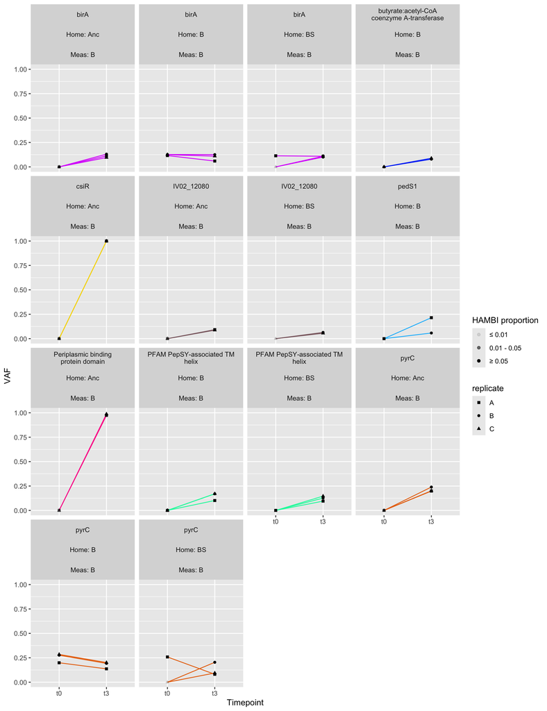

```r
plot$HAMBI_0006
```

## HAMBI_0403

Mutation in nfxB is known to result in overexpression of the MexCD-OprJ pump related to ciprofloxacin resitance. UvrY is involved in the regulation of carbon metabolism.

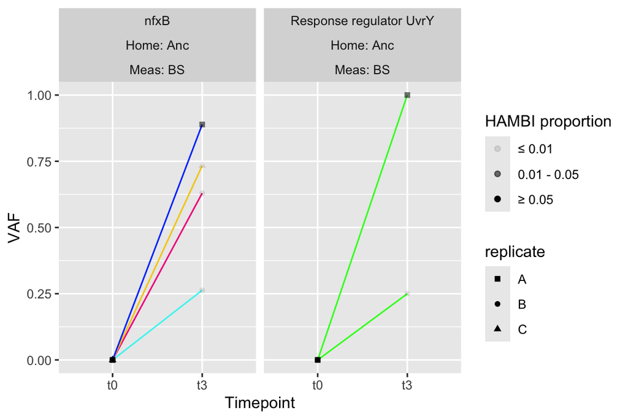

```r
plot$HAMBI_0403
```

## HAMBI_1287

Structural prediction of the H1287_01587 suggests that it is transmembrane protein EpsG.

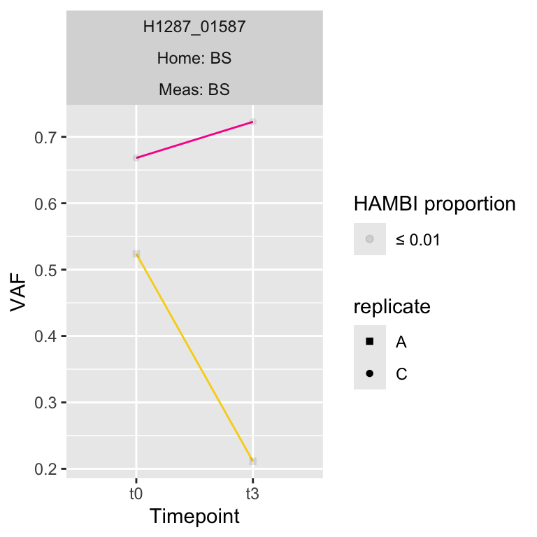

```r
plot$HAMBI_1287
```

## HAMBI_1842

PKHD-type hydroxylase seems to have acquired mutations during the experiment in all cases where the home environment had no streptomycin. BfrD and tonB associated with home Anc measurement streptomycin treatment combination.

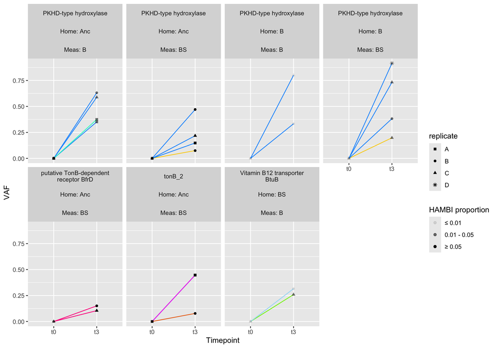

```r
plot$HAMBI_1842
```

## HAMBI_1972

Lot of variants in genes related to flagella.

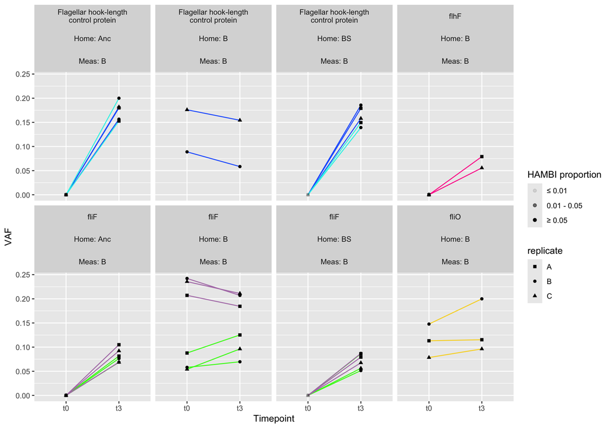

```r
plot$HAMBI_1972
```

## HAMBI_1977

Mutations of rsmG associated with (low-level) resistance to streptomycin.

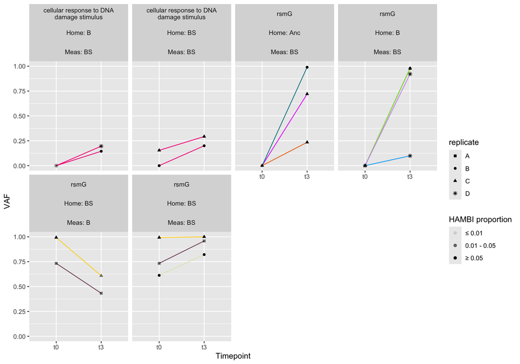

```r
plot$HAMBI_1977
```

## HAMBI_2443

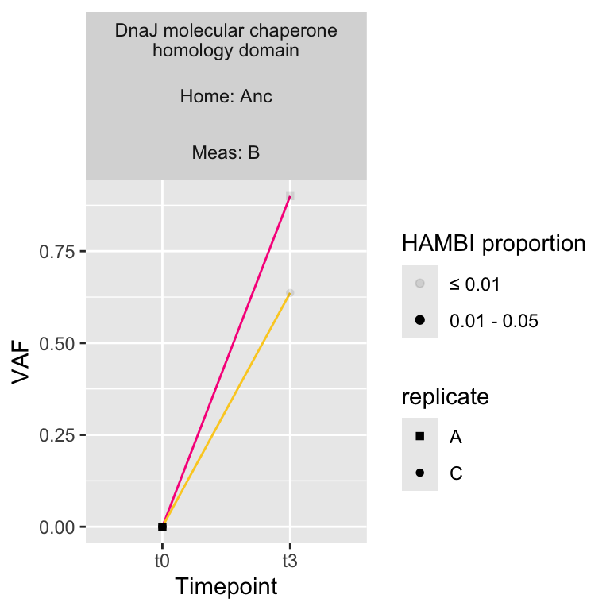

```r
plot$HAMBI_2443
```

## HAMBI_2659

AadR mutations seem to occur in low frequency with streptomycin.

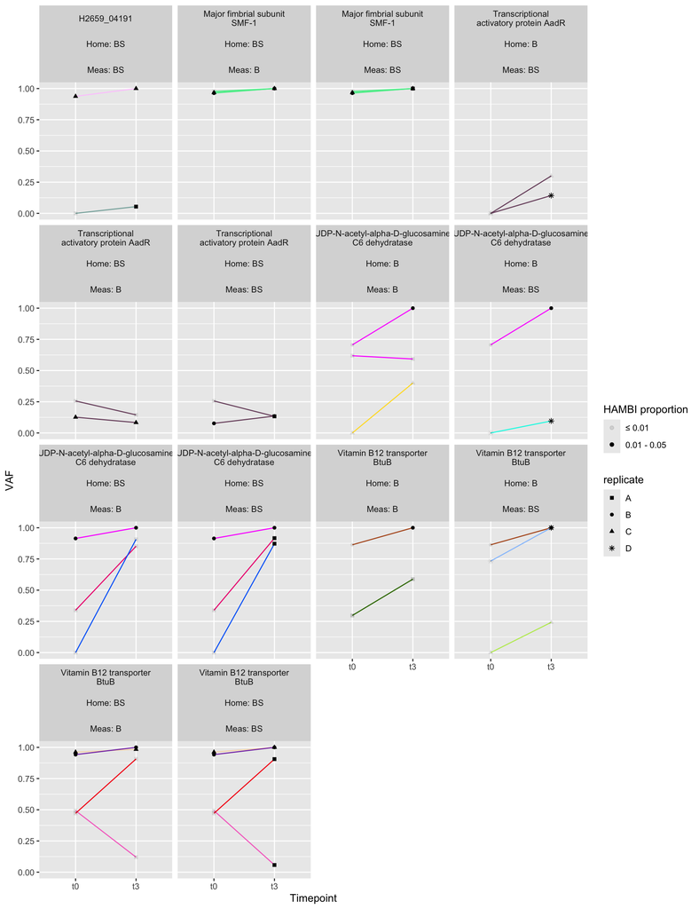

```r
plot$HAMBI_2659
```